# FAFB vs. FIBSEM

Load the libraries

```r
library(nat)
library(neuprintr)
library(neuprintrExtra)
library(tidyverse)
library(tidygraph)
library(ggraph)
library(gridExtra)
library(paletteer)
library(reshape2)
library(combinat)
library(cowplot)
source("FAFBvsFIBSEMUtils.R")
options(nat.plotengine = 'rgl')
```

Connect to neuprint

```r
neuprint_login()
```

Get the FAFB data in the PB

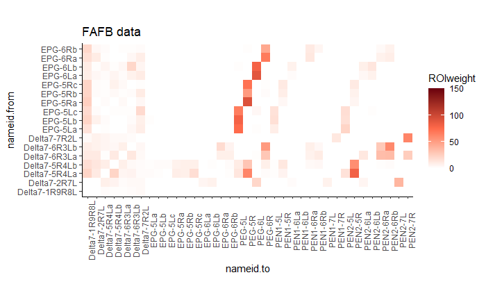

```r
FAFB_PB_df <-FAFBLoad("PB")
FAFB_PB_df <- FAFB_PB_df %>% filter(grepl("EPG",nameid.from) | grepl("Delta7",nameid.from))

gFAFB <- conMatPlot(FAFB_PB_df,150) + ggtitle("FAFB data")

print(gFAFB)
```

Get the FIBSEM data in the PB

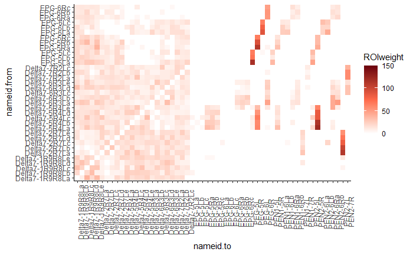

```r
neuronList = c("PEN_a\\\\\\\\(PB06a\\\\\\\\)_R5",
              "PEN_a\\\\\\\\(PB06a\\\\\\\\)_L5",
              "PEN_a\\\\\\\\(PB06a\\\\\\\\)_R6",
              "PEN_a\\\\\\\\(PB06a\\\\\\\\)_L6",
              "PEN_a\\\\\\\\(PB06a\\\\\\\\)_R7",
              "PEN_a\\\\\\\\(PB06a\\\\\\\\)_L7",
              "PEN_b\\\\\\\\(PB06b\\\\\\\\)_R5",
              "PEN_b\\\\\\\\(PB06b\\\\\\\\)_L5",
              "PEN_b\\\\\\\\(PB06b\\\\\\\\)_R6",
              "PEN_b\\\\\\\\(PB06b\\\\\\\\)_L6",
              "PEN_b\\\\\\\\(PB06b\\\\\\\\)_R7",
              "PEN_b\\\\\\\\(PB06b\\\\\\\\)_L7",
              "EPG\\\\\\\\(PB08\\\\\\\\)_R5",
              "EPG\\\\\\\\(PB08\\\\\\\\)_L5",
              "EPG\\\\\\\\(PB08\\\\\\\\)_R6",
              "EPG\\\\\\\\(PB08\\\\\\\\)_L6",
              "PEG\\\\\\\\(PB07\\\\\\\\)_R5",
              "PEG\\\\\\\\(PB07\\\\\\\\)_L5",
              "PEG\\\\\\\\(PB07\\\\\\\\)_R6",
              "PEG\\\\\\\\(PB07\\\\\\\\)_L6",
              "Delta7\\\\\\\\(PB15\\\\\\\\)_L7R2",
              "Delta7\\\\\\\\(PB15\\\\\\\\)_L6R3",
              "Delta7\\\\\\\\(PB15\\\\\\\\)_L5R4",
              "Delta7\\\\\\\\(PB15\\\\\\\\)_L2R7",
              "Delta7\\\\\\\\(PB15\\\\\\\\)_L1")

FIBSEM_PB <- FIBSEMLoad(neuronList,"PB") %>% filter(grepl("Delta7",nameid.from) | grepl("EPG",nameid.from))

gFIBSEM <-conMatPlot(FIBSEM_PB,150)

print(gFIBSEM)

ggsave("FIBSEM_PB.pdf", plot = gFIBSEM, device='pdf',
       path = "plots\\",
       scale = 1.5, width = 20, height = 15, units ="cm", dpi = 600, limitsize = TRUE)
```

Downselect the FIBSEM neurons for a direct comparison

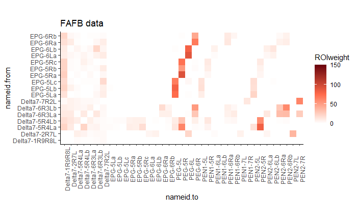

```r
DSneuronList <- c("EPG-6R",
                  "EPG-6L",
                  "Delta7-7R",
                  "Delta7-6R",
                  "Delta7-5R",
                  "Delta7-2R",
                  "Delta7-1R")
numNrons <-  c(2,2,1,2,2,1,1)

FIBSEM_PB_Cut <- FIBSEMDownSel(FIBSEM_PB, DSneuronList, numNrons)

gFIBSEM_DS <-conMatPlot(FIBSEM_PB_Cut,150) + ggtitle("select FIBSEM data")

print(gFAFB)
```

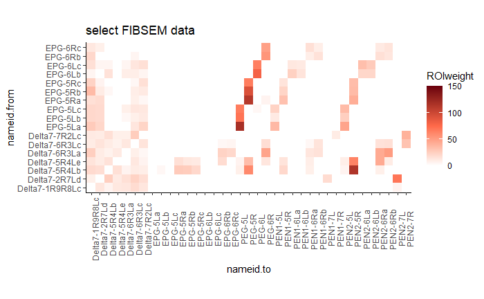

```r
print(gFIBSEM_DS)
```

Compare the two matrices

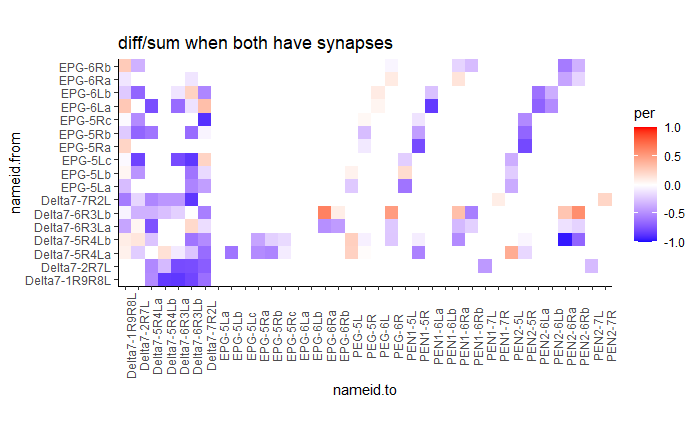

```r
PBComp <- datComp(FAFB_PB_df,FIBSEM_PB_Cut)
gPer <- ggplot(PBComp) +
  theme_classic() + theme(axis.text.x = element_text(angle = 90)) +
  scale_fill_gradient2(low="blue", mid="white", high="red", midpoint =0, limits=c(-1,1)) +
  geom_tile(aes(nameid.to,nameid.from,fill=per))+coord_fixed(ratio=1,expand=FALSE) + ggtitle("diff/sum when both have synapses")

gDiff <- ggplot(PBComp) +
  theme_classic() + theme(axis.text.x = element_text(angle = 90)) +
  scale_fill_gradient2(low="blue", mid="white", high="red", midpoint =0, limits=c(-30,30)) +
  geom_tile(aes(nameid.to,nameid.from,fill=diff))+coord_fixed(ratio=1,expand=FALSE) + ggtitle("synapses for only one dataset")

print(gPer)
```

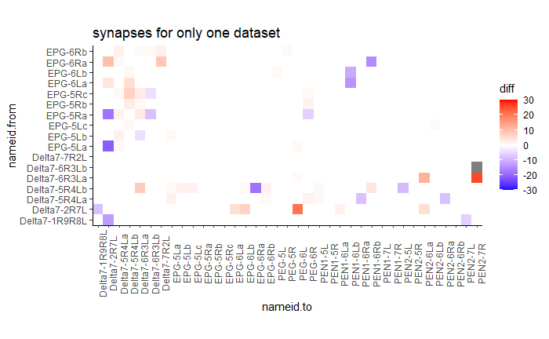

```r
print(gDiff)
```

Put them all on one plot and compare

```r
pdf("plots\\PBComp_test.pdf", width = 20, height = 20)
print(grid.arrange(gFAFB,gFIBSEM_DS,gPer,gDiff,
                   layout_matrix = rbind(c(1,2),c(3,4))))
```

| z | cells | name | grob |
| --- | --- | --- | --- |
| 1 | (1-1,1-1) | arrange | gtable[layout] |
| 2 | (1-1,2-2) | arrange | gtable[layout] |
| 3 | (2-2,1-1) | arrange | gtable[layout] |
| 4 | (2-2,2-2) | arrange | gtable[layout] |

```r
dev.off()
```

Just plot EPG and D7 connections in the PB

```r
pdf("plots\\PBEPGsD7s_FIBSEM_test.pdf", width = 10, height = 10)
print(gFIBSEM)
dev.off()
```

Just plot EPG and PEN1 connections in the PB

```r
neuronList = c("EPG\\\\\\\\(PB08\\\\\\\\)_R5",
              "EPG\\\\\\\\(PB08\\\\\\\\)_L5",
              "EPG\\\\\\\\(PB08\\\\\\\\)_R6",
              "EPG\\\\\\\\(PB08\\\\\\\\)_L6",
              "PEN_a\\\\\\\\(PB06a\\\\\\\\)_R5",
              "PEN_a\\\\\\\\(PB06a\\\\\\\\)_L5",
              "PEN_a\\\\\\\\(PB06a\\\\\\\\)_R6",
              "PEN_a\\\\\\\\(PB06a\\\\\\\\)_L6",
              "PEN_a\\\\\\\\(PB06a\\\\\\\\)_R7",
              "PEN_a\\\\\\\\(PB06a\\\\\\\\)_L7")

FIBSEM_PB <- FIBSEMLoad(neuronList,"PB")
FIBSEM_PB <- FAFBSort(FIBSEM_PB,"PB-subset")

gFIBSEM <-conMatPlot(FIBSEM_PB,40) +
  geom_hline(yintercept = 12.5) + geom_vline(xintercept = 12.5)

print(gFIBSEM)

pdf("plots\\PBEPGsPEN1s_FIBSEM_test.pdf", width = 5, height = 5)
```

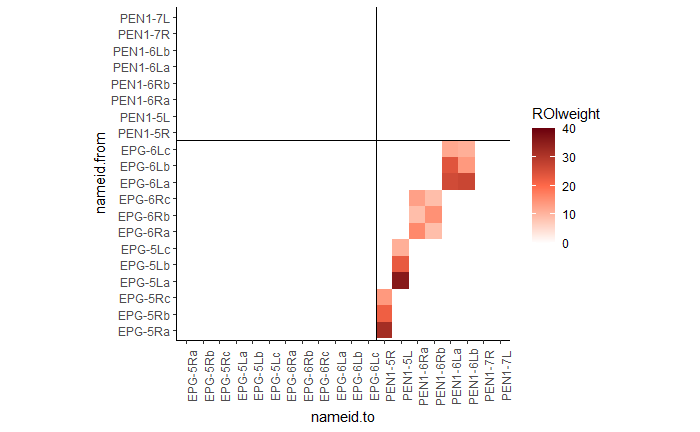

```r
print(gFIBSEM)
dev.off()
```

Just plot EPG, Delta7, PEN2, and PEG connections in the PB

```r
neuronList = c("EPG\\\\\\\\(PB08\\\\\\\\)_R5",
              "EPG\\\\\\\\(PB08\\\\\\\\)_L5",
              "EPG\\\\\\\\(PB08\\\\\\\\)_R6",
              "EPG\\\\\\\\(PB08\\\\\\\\)_L6",
              "PEN_b\\\\\\\\(PB06b\\\\\\\\)_R5",
              "PEN_b\\\\\\\\(PB06b\\\\\\\\)_L5",
              "PEN_b\\\\\\\\(PB06b\\\\\\\\)_R6",
              "PEN_b\\\\\\\\(PB06b\\\\\\\\)_L6",
              "PEN_b\\\\\\\\(PB06b\\\\\\\\)_R7",
              "PEN_b\\\\\\\\(PB06b\\\\\\\\)_L7",
              "PEG\\\\\\\\(PB07\\\\\\\\)_R5",
              "PEG\\\\\\\\(PB07\\\\\\\\)_L5",
              "PEG\\\\\\\\(PB07\\\\\\\\)_R6",
              "PEG\\\\\\\\(PB07\\\\\\\\)_L6",
              "Delta7\\\\\\\\(PB15\\\\\\\\)_L7R2",
              "Delta7\\\\\\\\(PB15\\\\\\\\)_L6R3",
              "Delta7\\\\\\\\(PB15\\\\\\\\)_L5R4",
              "Delta7\\\\\\\\(PB15\\\\\\\\)_L2R7",
              "Delta7\\\\\\\\(PB15\\\\\\\\)_L1")

FIBSEM_PB <- FIBSEMLoad(neuronList,"PB") %>%
  filter(grepl("Delta7",nameid.from) | grepl("EPG",nameid.from)) %>%
  filter(!grepl("Delta7",nameid.to) & !grepl("EPG",nameid.to))
FIBSEM_PB <- FAFBSort(FIBSEM_PB,"PB-subset")

gFIBSEM <-conMatPlot(FIBSEM_PB,150) +
  geom_hline(yintercept = 12.5) + geom_vline(xintercept = 8.5)

print(gFIBSEM)

pdf("plots\\PBEPGsD7sPEN2sPEGs_FIBSEM_test.pdf", width = 10, height = 10)
```

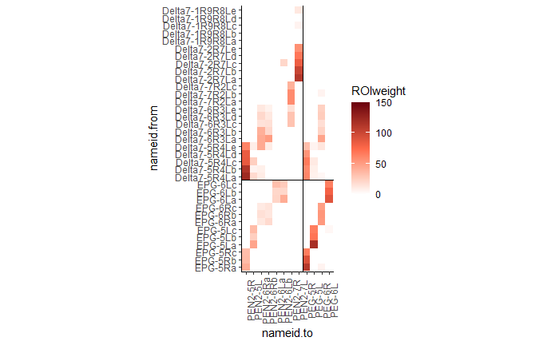

```r
print(gFIBSEM)
dev.off()
```

Just plot EPG, Delta7, and PEN1 in the PB

```r
neuronList = c("EPG\\\\\\\\(PB08\\\\\\\\)_R5",
              "EPG\\\\\\\\(PB08\\\\\\\\)_L5",
              "EPG\\\\\\\\(PB08\\\\\\\\)_R6",
              "EPG\\\\\\\\(PB08\\\\\\\\)_L6",
              "PEN_a\\\\\\\\(PB06a\\\\\\\\)_R5",
              "PEN_a\\\\\\\\(PB06a\\\\\\\\)_L5",
              "PEN_a\\\\\\\\(PB06a\\\\\\\\)_R6",
              "PEN_a\\\\\\\\(PB06a\\\\\\\\)_L6",
              "PEN_a\\\\\\\\(PB06a\\\\\\\\)_R7",
              "PEN_a\\\\\\\\(PB06a\\\\\\\\)_L7",
              "Delta7\\\\\\\\(PB15\\\\\\\\)_L7R2",
              "Delta7\\\\\\\\(PB15\\\\\\\\)_L6R3",
              "Delta7\\\\\\\\(PB15\\\\\\\\)_L5R4",
              "Delta7\\\\\\\\(PB15\\\\\\\\)_L2R7",
              "Delta7\\\\\\\\(PB15\\\\\\\\)_L1")

FIBSEM_PB <- FIBSEMLoad(neuronList,"PB") %>%
  filter(grepl("Delta7",nameid.from) | grepl("EPG",nameid.from)) %>%
  filter(!grepl("Delta7",nameid.to) & !grepl("EPG",nameid.to))
FIBSEM_PB <- FAFBSort(FIBSEM_PB,"PB-subset")

gFIBSEM <-conMatPlot(FIBSEM_PB,40) +
  geom_hline(yintercept = 12.5)

print(gFIBSEM)

pdf("plots\\PBEPGsD7sPEN1s_FIBSEM_test.pdf", width = 10, height = 10)
```

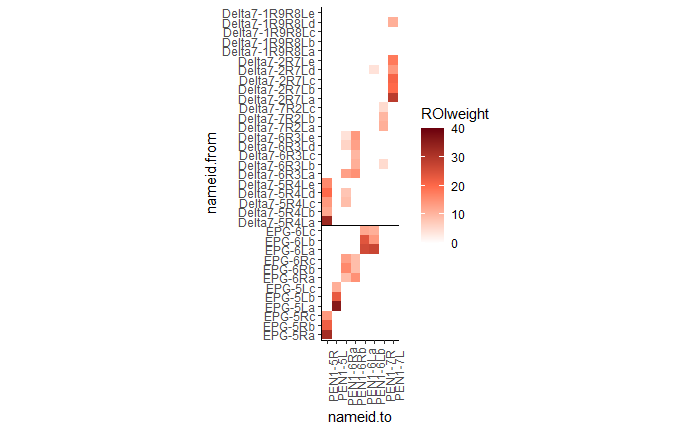

```r
print(gFIBSEM)
dev.off()
```

Compare the FAFB data to the FIBSEM data - EB

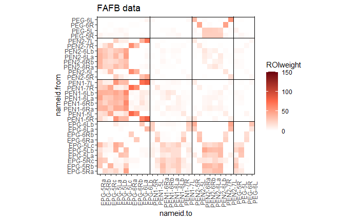

```r
FAFB_EB_df <-FAFBLoad("EB") %>%
  filter(!grepl("R4d",nameid.to) & !grepl("R4d",nameid.from))
FAFB_EB_df <-FAFBSort(FAFB_EB_df,"EB")

gFAFB <- conMatPlot(FAFB_EB_df,150) + geom_hline(yintercept = 10.5) + geom_hline(yintercept = 18.5) + geom_hline(yintercept = 26.5) + geom_hline(yintercept = 30.5) +
  geom_vline(xintercept = 10.5) + geom_vline(xintercept = 18.5) + geom_vline(xintercept = 26.5) + geom_vline(xintercept = 30.5) +
  ggtitle("FAFB data")

print(gFAFB)

ggsave("FAFB_EB_test.pdf", plot = gFAFB, device='pdf',
       path = "plots\\",
       scale = 1.5, width = 20, height = 15, units ="cm", dpi = 600, limitsize = TRUE)
```

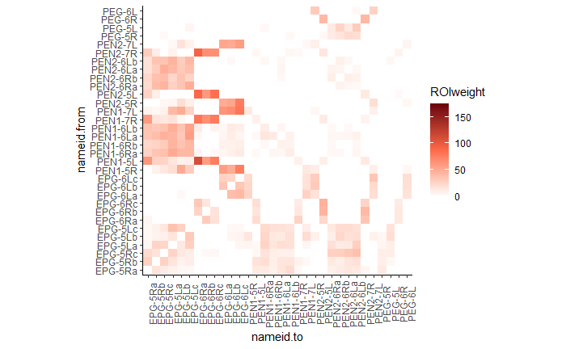

```r
neuronList = c("PEN_a\\\\\\\\(PB06a\\\\\\\\)_R5",
              "PEN_a\\\\\\\\(PB06a\\\\\\\\)_L5",
              "PEN_a\\\\\\\\(PB06a\\\\\\\\)_R6",
              "PEN_a\\\\\\\\(PB06a\\\\\\\\)_L6",
              "PEN_a\\\\\\\\(PB06a\\\\\\\\)_R7",
              "PEN_a\\\\\\\\(PB06a\\\\\\\\)_L7",
              "PEN_b\\\\\\\\(PB06b\\\\\\\\)_R5",
              "PEN_b\\\\\\\\(PB06b\\\\\\\\)_L5",
              "PEN_b\\\\\\\\(PB06b\\\\\\\\)_R6",
              "PEN_b\\\\\\\\(PB06b\\\\\\\\)_L6",
              "PEN_b\\\\\\\\(PB06b\\\\\\\\)_R7",
              "PEN_b\\\\\\\\(PB06b\\\\\\\\)_L7",
              "EPG\\\\\\\\(PB08\\\\\\\\)_R5",
              "EPG\\\\\\\\(PB08\\\\\\\\)_L5",
              "EPG\\\\\\\\(PB08\\\\\\\\)_R6",
              "EPG\\\\\\\\(PB08\\\\\\\\)_L6",
              "PEG\\\\\\\\(PB07\\\\\\\\)_R5",
              "PEG\\\\\\\\(PB07\\\\\\\\)_L5",
              "PEG\\\\\\\\(PB07\\\\\\\\)_R6",
              "PEG\\\\\\\\(PB07\\\\\\\\)_L6")#"R4d"

FIBSEM_EB <- FIBSEMLoad(neuronList,"EB")

gFIBSEM <-conMatPlot(FIBSEM_EB,175)

print(gFIBSEM)

ggsave("FIBSEM_EB_test.pdf", plot = gFIBSEM, device='pdf',
       path = "plots\\",
       scale = 1.5, width = 20, height = 15, units ="cm", dpi = 600, limitsize = TRUE)
```

Downselect the FIBSEM neurons for a direct comparison

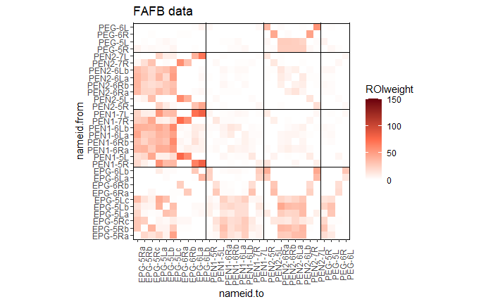

```r
DSneuronList <- c("EPG-6R",
                  "EPG-6L")
numNrons <-  c(2,2)#,7)

FIBSEM_EB_Cut <- FIBSEMDownSel(FIBSEM_EB, DSneuronList, numNrons)

gFIBSEM_DS <-conMatPlot(FIBSEM_EB_Cut,150) + ggtitle("select FIBSEM data") +
  geom_hline(yintercept = 10.5) + geom_hline(yintercept = 18.5) + geom_hline(yintercept = 26.5) + geom_hline(yintercept = 30.5) +
  geom_vline(xintercept = 10.5) + geom_vline(xintercept = 18.5) + geom_vline(xintercept = 26.5) + geom_vline(xintercept = 30.5)

print(gFAFB)
```

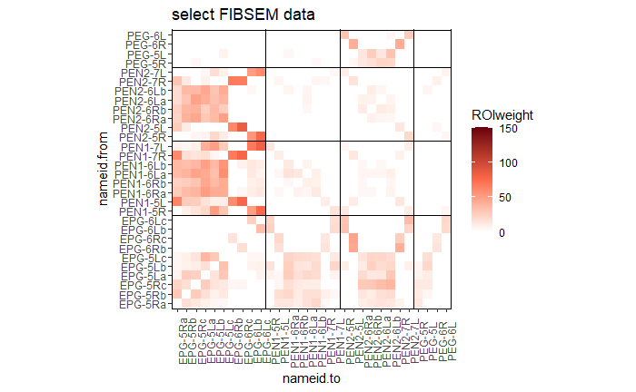

```r
print(gFIBSEM_DS)
```

Compare the two matrices

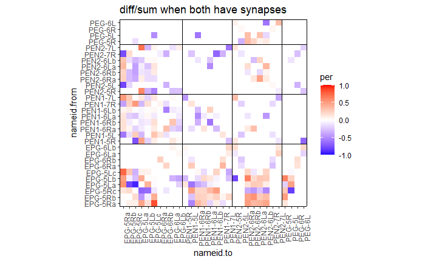

```r
EBComp <- datComp(FAFB_EB_df %>%
                    filter(!grepl("R4d",nameid.from) & !grepl("R4d",nameid.to)),
                  FIBSEM_EB_Cut)
gPer <- ggplot(EBComp) +
  theme_classic() + theme(axis.text.x = element_text(angle = 90)) +
  scale_fill_gradient2(low="blue", mid="white", high="red", midpoint =0, limits=c(-1,1)) +
  geom_tile(aes(nameid.to,nameid.from,fill=per))+coord_fixed(ratio=1,expand=FALSE) + ggtitle("diff/sum when both have synapses") +
  geom_hline(yintercept = 10.5) + geom_hline(yintercept = 18.5) + geom_hline(yintercept = 26.5) + geom_hline(yintercept = 30.5) +
  geom_vline(xintercept = 10.5) + geom_vline(xintercept = 18.5) + geom_vline(xintercept = 26.5) + geom_vline(xintercept = 30.5)

gDiff <- ggplot(EBComp) +
  theme_classic() + theme(axis.text.x = element_text(angle = 90)) +
  scale_fill_gradient2(low="blue", mid="white", high="red", midpoint =0, limits=c(-45,45)) +
  geom_tile(aes(nameid.to,nameid.from,fill=diff))+coord_fixed(ratio=1,expand=FALSE) + ggtitle("synapses for only one dataset") +
  geom_hline(yintercept = 10.5) + geom_hline(yintercept = 18.5) + geom_hline(yintercept = 26.5) + geom_hline(yintercept = 30.5) +
  geom_vline(xintercept = 10.5) + geom_vline(xintercept = 18.5) + geom_vline(xintercept = 26.5) + geom_vline(xintercept = 30.5)

print(gPer)
```

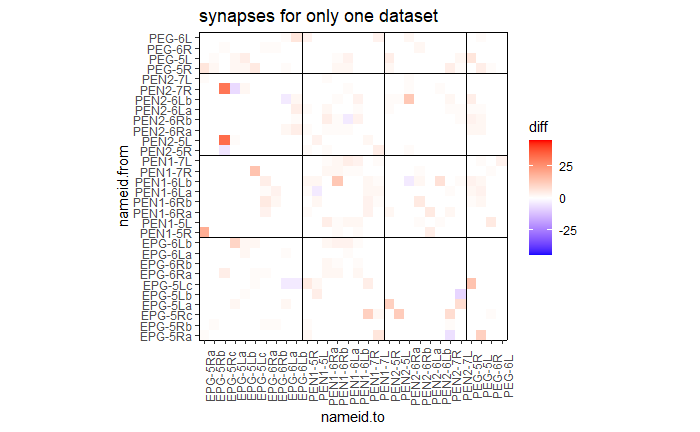

```r
print(gDiff)
```

Put them all on one plot and compare

```r
pdf("plots\\EBComp_test.pdf", width = 20, height = 20)
print(grid.arrange(gFAFB,gFIBSEM_DS,gPer,gDiff,
                   layout_matrix = rbind(c(1,2),c(3,4))))
```

| z | cells | name | grob |
| --- | --- | --- | --- |
| 1 | (1-1,1-1) | arrange | gtable[layout] |
| 2 | (1-1,2-2) | arrange | gtable[layout] |
| 3 | (2-2,1-1) | arrange | gtable[layout] |
| 4 | (2-2,2-2) | arrange | gtable[layout] |

```r
dev.off()
```

Just plot EPG to EPG connections in the EB

```r
neuronList = c("EPG\\\\\\\\(PB08\\\\\\\\)_R5",
              "EPG\\\\\\\\(PB08\\\\\\\\)_L5",
              "EPG\\\\\\\\(PB08\\\\\\\\)_R6",
              "EPG\\\\\\\\(PB08\\\\\\\\)_L6")

FIBSEM_EB <- FIBSEMLoad(neuronList,"EB")

gFIBSEM <-conMatPlot(FIBSEM_EB,100) +
  geom_hline(yintercept = 6.5) + geom_hline(yintercept = 9.5) +
  geom_vline(xintercept = 6.5) + geom_vline(xintercept = 9.5)

print(gFIBSEM)

pdf("plots\\EBEPGs_FIBSEM_test.pdf", width = 5, height = 5)
```

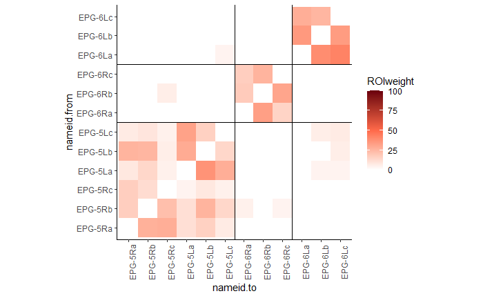

```r
print(gFIBSEM)
dev.off()
```

Just plot EPG and PEN1 connections in the EB

```r
neuronList = c("EPG\\\\\\\\(PB08\\\\\\\\)_R5",
              "EPG\\\\\\\\(PB08\\\\\\\\)_L5",
              "EPG\\\\\\\\(PB08\\\\\\\\)_R6",
              "EPG\\\\\\\\(PB08\\\\\\\\)_L6",
              "PEN_a\\\\\\\\(PB06a\\\\\\\\)_R5",
              "PEN_a\\\\\\\\(PB06a\\\\\\\\)_L5",
              "PEN_a\\\\\\\\(PB06a\\\\\\\\)_R6",
              "PEN_a\\\\\\\\(PB06a\\\\\\\\)_L6",
              "PEN_a\\\\\\\\(PB06a\\\\\\\\)_R7",
              "PEN_a\\\\\\\\(PB06a\\\\\\\\)_L7")

FIBSEM_EB <- FIBSEMLoad(neuronList,"EB")

gFIBSEM <-conMatPlot(FIBSEM_EB,120) +
  geom_hline(yintercept = 12.5) +
  geom_vline(xintercept = 12.5)

print(gFIBSEM)

pdf("plots\\EBEPGsPEN1s_FIBSEM_test.pdf", width = 5, height = 5)
```

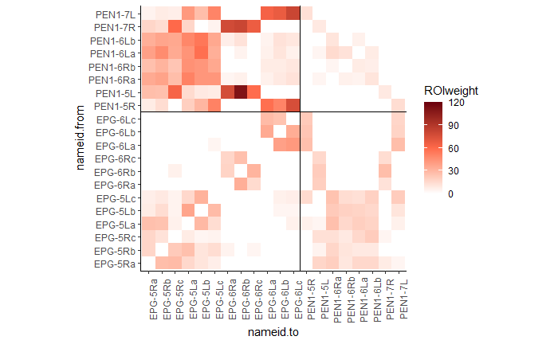

```r
print(gFIBSEM)
dev.off()
```

Just plot EPG, PEN2, and PEG connections in the EB

```r
neuronList = c("EPG\\\\\\\\(PB08\\\\\\\\)_R5",
              "EPG\\\\\\\\(PB08\\\\\\\\)_L5",
              "EPG\\\\\\\\(PB08\\\\\\\\)_R6",
              "EPG\\\\\\\\(PB08\\\\\\\\)_L6",
              "PEN_b\\\\\\\\(PB06b\\\\\\\\)_R5",
              "PEN_b\\\\\\\\(PB06b\\\\\\\\)_L5",
              "PEN_b\\\\\\\\(PB06b\\\\\\\\)_R6",
              "PEN_b\\\\\\\\(PB06b\\\\\\\\)_L6",
              "PEN_b\\\\\\\\(PB06b\\\\\\\\)_R7",
              "PEN_b\\\\\\\\(PB06b\\\\\\\\)_L7",
              "PEG\\\\\\\\(PB07\\\\\\\\)_R5",
              "PEG\\\\\\\\(PB07\\\\\\\\)_L5",
              "PEG\\\\\\\\(PB07\\\\\\\\)_R6",
              "PEG\\\\\\\\(PB07\\\\\\\\)_L6")

FIBSEM_EB <- FIBSEMLoad(neuronList,"EB")

gFIBSEM <-conMatPlot(FIBSEM_EB,100) +
  geom_tile(aes(nameid.to,nameid.from,fill=ROIweight))+coord_fixed(ratio=1) +
  geom_hline(yintercept = 12.5) + geom_hline(yintercept = 20.5) +
  geom_vline(xintercept = 12.5) + geom_vline(xintercept = 20.5)
print(gFIBSEM)

pdf("plots\\EBEPGsPEN2sPEGs_FIBSEM_test.pdf", width = 5, height = 5)
```

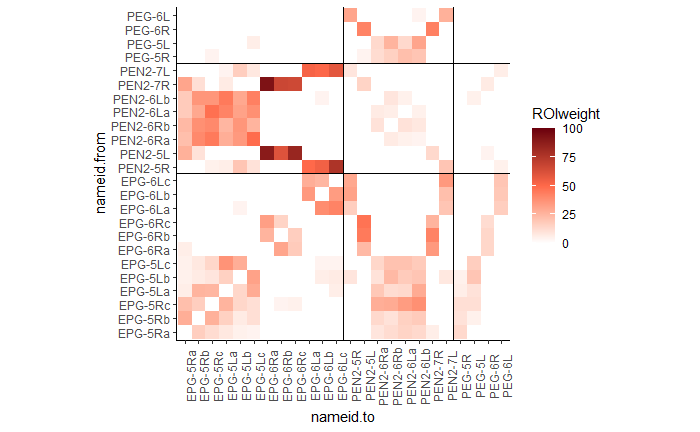

```r
print(gFIBSEM)
dev.off()
```

Compare the FAFB data to the FIBSEM data - NO

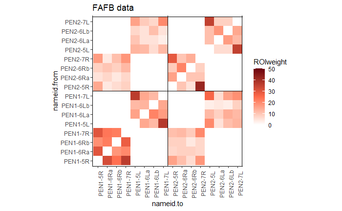

```r
FAFB_NO_df <-FAFBLoad("NO")
FAFB_NO_df <- FAFBSort(FAFB_NO_df,"NO")

gFAFB <- conMatPlot(FAFB_NO_df,50) +
  ggtitle("FAFB data")  +
  geom_hline(yintercept = 8.5) + geom_vline(xintercept = 8.5) +
  geom_hline(yintercept = 16.5) + geom_vline(xintercept = 16.5)

ggsave("FAFB_NO.pdf", plot = last_plot(), device='pdf',
       path = "plots\\",
       scale = 1.5, width = 20, height = 15, units ="cm", dpi = 600, limitsize = TRUE)

print(gFAFB)
```

```r
neuronList = c("PEN_a\\\\\\\\(PB06a\\\\\\\\)_R5",
              "PEN_a\\\\\\\\(PB06a\\\\\\\\)_L5",
              "PEN_a\\\\\\\\(PB06a\\\\\\\\)_R6",
              "PEN_a\\\\\\\\(PB06a\\\\\\\\)_L6",
              "PEN_a\\\\\\\\(PB06a\\\\\\\\)_R7",
              "PEN_a\\\\\\\\(PB06a\\\\\\\\)_L7",
              "PEN_b\\\\\\\\(PB06b\\\\\\\\)_R5",
              "PEN_b\\\\\\\\(PB06b\\\\\\\\)_L5",
              "PEN_b\\\\\\\\(PB06b\\\\\\\\)_R6",
              "PEN_b\\\\\\\\(PB06b\\\\\\\\)_L6",
              "PEN_b\\\\\\\\(PB06b\\\\\\\\)_R7",
              "PEN_b\\\\\\\\(PB06b\\\\\\\\)_L7")

FIBSEM_NO <- FIBSEMLoad(neuronList,"NO") %>% filter(!is.na(nameid.from) & !is.na(nameid.to))

gFIBSEM <-conMatPlot(FIBSEM_NO,50) +
  geom_hline(yintercept = 8.5) + geom_vline(xintercept = 8.5) +
  geom_hline(yintercept = 16.5) + geom_vline(xintercept = 16.5)

pdf("plots\\NOPENs_FIBSEM.pdf", width = 5, height = 5)
print(gFIBSEM)

gFIBSEM <- gFIBSEM + ggtitle("FIBSEM data") +
  geom_hline(yintercept = 8.5) + geom_vline(xintercept = 8.5) +
  geom_hline(yintercept = 16.5) + geom_vline(xintercept = 16.5)

ggsave("FIBSEM_NO.pdf", plot = last_plot(), device='pdf',
       path = "plots\\",
       scale = 1.5, width = 20, height = 15, units ="cm", dpi = 600, limitsize = TRUE)
```

Compare the two matrices

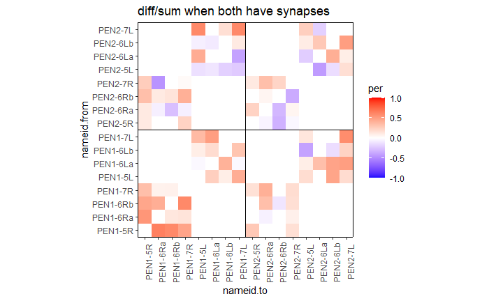

```r
NOComp <- datComp(FAFB_NO_df,FIBSEM_NO)
gPer <- ggplot(NOComp) +
  theme_classic() + theme(axis.text.x = element_text(angle = 90)) +
  scale_fill_gradient2(low="blue", mid="white", high="red", midpoint =0, limits=c(-1,1)) +
  geom_tile(aes(nameid.to,nameid.from,fill=per))+coord_fixed(ratio=1,expand=FALSE) + ggtitle("diff/sum when both have synapses") +
  geom_hline(yintercept = 8.5) + geom_vline(xintercept = 8.5) +
  geom_hline(yintercept = 16.5) + geom_vline(xintercept = 16.5)

gDiff <- ggplot(NOComp) +
  theme_classic() + theme(axis.text.x = element_text(angle = 90)) +
  scale_fill_gradient2(low="blue", mid="white", high="red", midpoint =0, limits=c(-45,45)) +
  geom_tile(aes(nameid.to,nameid.from,fill=diff))+coord_fixed(ratio=1,expand=FALSE) + ggtitle("synapses for only one dataset") +
  geom_hline(yintercept = 8.5) + geom_vline(xintercept = 8.5) +
  geom_hline(yintercept = 16.5) + geom_vline(xintercept = 16.5)

print(gPer)
```

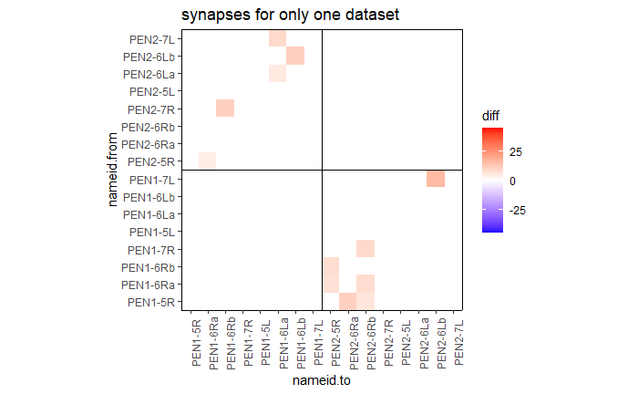

```r
print(gDiff)
```

Put them all on one plot and compare

```r
pdf("plots\\NOComp_test.pdf", width = 20, height = 20)
print(grid.arrange(gFAFB,gFIBSEM,gPer,gDiff,
                   layout_matrix = rbind(c(1,2),c(3,4))))
```

| z | cells | name | grob |
| --- | --- | --- | --- |
| 1 | (1-1,1-1) | arrange | gtable[layout] |
| 2 | (1-1,2-2) | arrange | gtable[layout] |
| 3 | (2-2,1-1) | arrange | gtable[layout] |
| 4 | (2-2,2-2) | arrange | gtable[layout] |

```r
dev.off()
```

Just plot PEN1 connections in the NO

```r
neuronList = c("PEN_a\\\\\\\\(PB06a\\\\\\\\)_R5",
              "PEN_a\\\\\\\\(PB06a\\\\\\\\)_L5",
              "PEN_a\\\\\\\\(PB06a\\\\\\\\)_R6",
              "PEN_a\\\\\\\\(PB06a\\\\\\\\)_L6",
              "PEN_a\\\\\\\\(PB06a\\\\\\\\)_R7",
              "PEN_a\\\\\\\\(PB06a\\\\\\\\)_L7")

FIBSEM_NO <- FIBSEMLoad(neuronList,"NO")

gFIBSEM <-conMatPlot(FIBSEM_NO,50) +
  geom_hline(yintercept = 4.5) +
  geom_vline(xintercept = 4.5)

print(gFIBSEM)

pdf("plots\\NOPEN1s_FIBSEM.pdf", width = 5, height = 5)
```

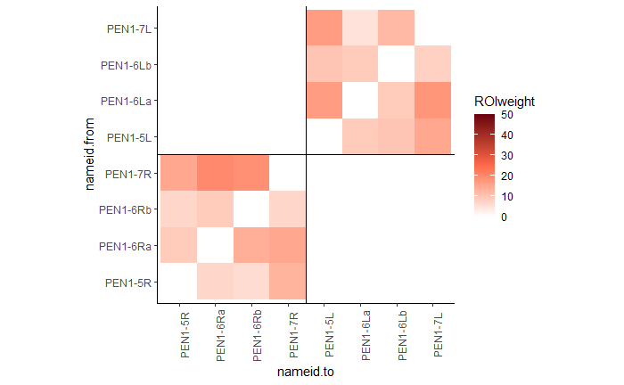

```r
print(gFIBSEM)
dev.off()
```

Find the difference in connections between neurons in the PB

```r
# Pull the FAFB data
FAFB_PB_df <-FAFBLoad("PB")
FAFB_PB_df <- FAFB_PB_df %>% filter(grepl("EPG",nameid.from) | grepl("Delta7",nameid.from))

# Pull the FIBSEM data
neuronList = c("PEN_a\\\\\\\\(PB06a\\\\\\\\)_R5",
              "PEN_a\\\\\\\\(PB06a\\\\\\\\)_L5",
              "PEN_a\\\\\\\\(PB06a\\\\\\\\)_R6",
              "PEN_a\\\\\\\\(PB06a\\\\\\\\)_L6",
              "PEN_a\\\\\\\\(PB06a\\\\\\\\)_R7",
              "PEN_a\\\\\\\\(PB06a\\\\\\\\)_L7",
              "PEN_b\\\\\\\\(PB06b\\\\\\\\)_R5",
              "PEN_b\\\\\\\\(PB06b\\\\\\\\)_L5",
              "PEN_b\\\\\\\\(PB06b\\\\\\\\)_R6",
              "PEN_b\\\\\\\\(PB06b\\\\\\\\)_L6",
              "PEN_b\\\\\\\\(PB06b\\\\\\\\)_R7",
              "PEN_b\\\\\\\\(PB06b\\\\\\\\)_L7",
              "EPG\\\\\\\\(PB08\\\\\\\\)_R5",
              "EPG\\\\\\\\(PB08\\\\\\\\)_L5",
              "EPG\\\\\\\\(PB08\\\\\\\\)_R6",
              "EPG\\\\\\\\(PB08\\\\\\\\)_L6",
              "PEG\\\\\\\\(PB07\\\\\\\\)_R5",
              "PEG\\\\\\\\(PB07\\\\\\\\)_L5",
              "PEG\\\\\\\\(PB07\\\\\\\\)_R6",
              "PEG\\\\\\\\(PB07\\\\\\\\)_L6",
              "Delta7\\\\\\\\(PB15\\\\\\\\)_L7R2",
              "Delta7\\\\\\\\(PB15\\\\\\\\)_L6R3",
              "Delta7\\\\\\\\(PB15\\\\\\\\)_L5R4",
              "Delta7\\\\\\\\(PB15\\\\\\\\)_L2R7",
              "Delta7\\\\\\\\(PB15\\\\\\\\)_L1")
FIBSEM_PB <- FIBSEMLoad(neuronList,"PB") %>% filter(grepl("Delta7",nameid.from) | grepl("EPG",nameid.from))
```

Find the difference in connections between neurons in the EB

```r
# Pull the FAFB data
FAFB_EB_df <-FAFBLoad("EB")
FAFB_EB_df <- FAFB_EB_df %>% filter(!grepl("GE-r1",nameid.from) & !grepl("GE-r1",nameid.to)) %>%
  filter(!grepl("R4d",nameid.from) & !grepl("R4d",nameid.to))

# Pull the FIBSEM data
neuronList = c("PEN_a\\\\\\\\(PB06a\\\\\\\\)_R5",
              "PEN_a\\\\\\\\(PB06a\\\\\\\\)_L5",
              "PEN_a\\\\\\\\(PB06a\\\\\\\\)_R6",
              "PEN_a\\\\\\\\(PB06a\\\\\\\\)_L6",
              "PEN_a\\\\\\\\(PB06a\\\\\\\\)_R7",
              "PEN_a\\\\\\\\(PB06a\\\\\\\\)_L7",
              "PEN_b\\\\\\\\(PB06b\\\\\\\\)_R5",
              "PEN_b\\\\\\\\(PB06b\\\\\\\\)_L5",
              "PEN_b\\\\\\\\(PB06b\\\\\\\\)_R6",
              "PEN_b\\\\\\\\(PB06b\\\\\\\\)_L6",
              "PEN_b\\\\\\\\(PB06b\\\\\\\\)_R7",
              "PEN_b\\\\\\\\(PB06b\\\\\\\\)_L7",
              "EPG\\\\\\\\(PB08\\\\\\\\)_R5",
              "EPG\\\\\\\\(PB08\\\\\\\\)_L5",
              "EPG\\\\\\\\(PB08\\\\\\\\)_R6",
              "EPG\\\\\\\\(PB08\\\\\\\\)_L6",
              "PEG\\\\\\\\(PB07\\\\\\\\)_R5",
              "PEG\\\\\\\\(PB07\\\\\\\\)_L5",
              "PEG\\\\\\\\(PB07\\\\\\\\)_R6",
              "PEG\\\\\\\\(PB07\\\\\\\\)_L6")
FIBSEM_EB <- FIBSEMLoad(neuronList,"EB")

allMetrics_EB <- permuteComp(FAFB_EB_df, FIBSEM_EB,"EB",200)
```

Find the difference in connections between neurons in the NO

```r
# Pull the FAFB data
FAFB_NO_df <-FAFBLoad("NO")
FAFB_NO_df <- FAFB_NO_df %>% filter(!grepl("NO-LAL-G",nameid.from) & !grepl("NO-LAL-G",nameid.to))


# Pull the FIBSEM data
neuronList = c("PEN_a\\\\\\\\(PB06a\\\\\\\\)_R5",
              "PEN_a\\\\\\\\(PB06a\\\\\\\\)_L5",
              "PEN_a\\\\\\\\(PB06a\\\\\\\\)_R6",
              "PEN_a\\\\\\\\(PB06a\\\\\\\\)_L6",
              "PEN_a\\\\\\\\(PB06a\\\\\\\\)_R7",
              "PEN_a\\\\\\\\(PB06a\\\\\\\\)_L7",
              "PEN_b\\\\\\\\(PB06b\\\\\\\\)_R5",
              "PEN_b\\\\\\\\(PB06b\\\\\\\\)_L5",
              "PEN_b\\\\\\\\(PB06b\\\\\\\\)_R6",
              "PEN_b\\\\\\\\(PB06b\\\\\\\\)_L6",
              "PEN_b\\\\\\\\(PB06b\\\\\\\\)_R7",
              "PEN_b\\\\\\\\(PB06b\\\\\\\\)_L7")
FIBSEM_NO <- FIBSEMLoad(neuronList,"NO")

allMetrics_NO <- permuteComp(FAFB_NO_df, FIBSEM_NO,"NO",200)
```

```
Argument m has 4 elements: only the first usedArgument m has 4 elements: only the first usedArgument m has 4 elements: only the first usedArgument m has 4 elements: only the first usedUsing ROIweight as value column: use value.var to override.
```

Plot the different metrics

```r
# Plot the differences
allDiffs <- data.frame(d = allMetrics_EB %>% filter(diff != 0) %>% select(diff),
                       region = "EB")
allDiffs <- rbind(allDiffs,
                  data.frame(d = allMetrics_PB %>% filter(diff != 0) %>% select(diff),
                             region = "PB"))
allDiffs <- rbind(allDiffs,
                  data.frame(d = allMetrics_NO %>% filter(diff != 0) %>% select(diff),
                             region = "NO"))
allDiffs$region <- factor(allDiffs$region, levels = c("PB","EB","NO"))
diffPlot <- ggplot(allDiffs,aes(x=region,y=diff,fill=region)) + geom_violin() +
  theme_minimal_hgrid() + ylab('FIBSEM cts       FAFB cts') +
  theme(axis.title = element_text(size = 8),
      axis.text = element_text(size = 6),
      legend.text = element_text(size = 6),
      legend.title = element_text(size = 8))

# Plot the ratios
allPers <- data.frame(per = allMetrics_EB %>% filter(per != 0 | equal !=0 ) %>% select(per),
                       region = "EB")
allPers <- rbind(allPers,
                  data.frame(per = allMetrics_PB %>% filter(per != 0 | equal !=0 ) %>% select(per),
                             region = "PB"))
allPers <- rbind(allPers,
                  data.frame(per = allMetrics_NO %>% filter(per != 0 | equal !=0 ) %>% select(per),
                             region = "NO"))
allPers$region <- factor(allPers$region, levels = c("PB","EB","NO"))
perPlot <- ggplot(allPers,aes(x=region,y=per,fill=region)) + geom_violin() +
  theme_minimal_hgrid() + ylab('(FAFB cts − FIBSEM cts)/(total cts)') + ylim(-1,1) +
  theme(axis.title = element_text(size = 8),
      axis.text = element_text(size = 6),
      legend.text = element_text(size = 6),
      legend.title = element_text(size = 8))

pdf("plots\\FAFBVsFIBSEMComp.pdf", width = unit(8,"in"), height = unit(11,"in"))
plot_grid(gFAFB,gFIBSEM,gPer,gDiff,perPlot, diffPlot,
          labels = c('A','B','C','D','E','F'), label_size = 8,
          ncol=2,
          rel_heights = c(1,1,0.5))
dev.off()
```